# week08_in_class

```python
import numpy as np
import matplotlib.pyplot as plt
```

Quiz 6, q4

```python
np.arange(3.4, 4.41, 0.25)
```

```
array([3.4 , 3.65, 3.9 , 4.15, 4.4 ])
```

```python
np.arange(3.4, 4.4, 0.25)
```

```
array([3.4 , 3.65, 3.9 , 4.15, 4.4 ])
```

Quiz 7, q4

```python
pippo = np.arange(1,41).reshape(4,10)
x=np.arange(1,5).reshape(2,2)
pippo[1:3,4:6]=x
pippo
```

```
array([[ 1,  2,  3,  4,  5,  6,  7,  8,  9, 10],
       [11, 12, 13, 14,  1,  2, 17, 18, 19, 20],
       [21, 22, 23, 24,  3,  4, 27, 28, 29, 30],
       [31, 32, 33, 34, 35, 36, 37, 38, 39, 40]])
```

Create a boolean array that is `True` where the elements of `pippo` are odd or a multiple of 7

```python
b=(pippo%2 == 1) | (pippo%7 == 0)
```

```python
pippo[b]
```

```
array([ 1,  3,  5,  7,  9, 11, 13, 14,  1, 17, 19, 21, 23,  3, 27, 28, 29,
       31, 33, 35, 37, 39])
```

(7) Set all the elements of pippo that are even equal to 300

```python
pippo[pippo%2==0] =300
pippo
```

```
array([[  1, 300,   3, 300,   5, 300,   7, 300,   9, 300],
       [ 11, 300,  13, 300,   1, 300,  17, 300,  19, 300],
       [ 21, 300,  23, 300,   3, 300,  27, 300,  29, 300],
       [ 31, 300,  33, 300,  35, 300,  37, 300,  39, 300]])
```

(8) Write the code that creates a 3 × 4 array a with numbers from 0 to 11. Use boolean indeces to set all of the entries of a, that are less than 2 or greater than 8, equal to 0.

```python
a=np.arange(0,12).reshape(3,4)
b=(a<2) | (a>8)
a[ b ] = 0
```

```python
a
```

```
array([[0, 0, 2, 3],
       [4, 5, 6, 7],
       [8, 0, 0, 0]])
```

## Specifying colors in matplotlib

### Colormaps

set of colors the you can select in the range [0,1)

```python
import matplotlib.cm as cm # a collection of color maps
```

```python
dir(cm)
```

```
['Accent',
 'Accent_r',
 'Blues',
 'Blues_r',
 'BrBG',
 'BrBG_r',
 'BuGn',
 'BuGn_r',
 'BuPu',
 'BuPu_r',
 'CMRmap',
 'CMRmap_r',
 'Dark2',
 'Dark2_r',
 'GnBu',
 'GnBu_r',
 'Greens',
 'Greens_r',
 'Greys',
 'Greys_r',
 'LUTSIZE',
 'OrRd',
 'OrRd_r',
 'Oranges',
 'Oranges_r',
 'PRGn',
 'PRGn_r',
 'Paired',
 'Paired_r',
 'Pastel1',
 'Pastel1_r',
 'Pastel2',
 'Pastel2_r',
 'PiYG',
 'PiYG_r',
 'PuBu',
 'PuBuGn',
 'PuBuGn_r',
 'PuBu_r',
 'PuOr',
```

[output cut: 135 more lines]

```
 'tab20_r',
 'tab20b',
 'tab20b_r',
 'tab20c',
 'tab20c_r',
 'terrain',
 'terrain_r',
 'twilight',
 'twilight_r',
 'twilight_shifted',
 'twilight_shifted_r',
 'viridis',
 'viridis_r',
 'winter',
 'winter_r']
```

```python
print(cm.terrain(0.5))
```

```
(0.996078431372549, 0.9949803921568627, 0.5978823529411764, 1.0)
```

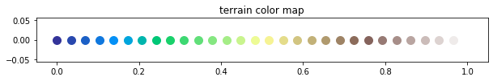

```python
x = np.linspace(0,1,30)

plt.figure(figsize=(10,1))
for k in x:
    plt.plot(k,0,'o',ms=10,color=cm.terrain(k))
plt.title('terrain color map')
plt.show()
```

```python
cm.terrain(0)
```

```
(0.2, 0.2, 0.6, 1.0)
```

```python
y=x.reshape(5,2,3)
plt.imsave('image.png',y)
```

```python
x=np.random.rand(100,100,3)
plt.imsave('image.png',x)
```

**Ex.** Create a 2x2 plot of the seasons. Create a graph similar to the `terrain` color map, using the color map of each season

Each subplot should have a title with the corresponding season, The whole image should have a supertitle `plt.suptitle` with your name on it.

One you have it, post it on discord in the channel 'seasons'

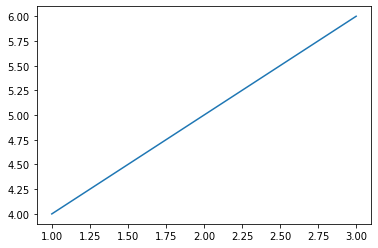

```python
plt.plot([1,2,3],[4,5,6])
plt.savefig('image2.png')
```

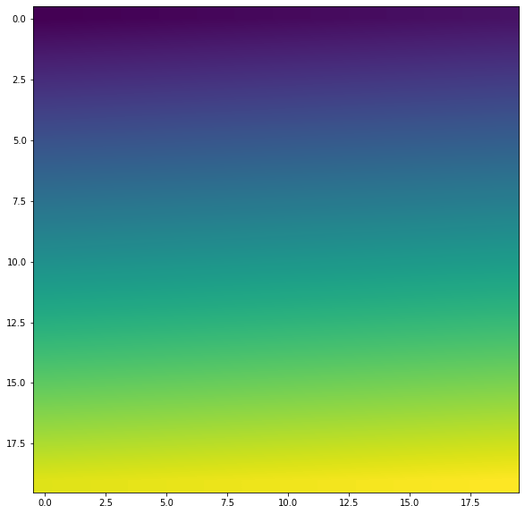

```python
x=np.linspace(0,1,400).reshape(20,-1)
plt.figure(figsize=(10,10))
plt.imshow(x,cmap='viridis',interpolation='bilinear');
```

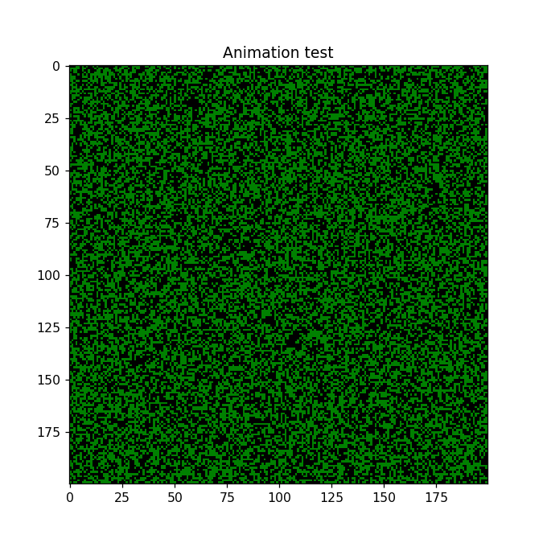

```python
%matplotlib notebook



import numpy as np
import matplotlib.pyplot as plt
from matplotlib.animation import FuncAnimation
from matplotlib import colors

x = np.zeros((200,200), dtype = int)

fig = plt.figure(figsize = (6,6))
ax = plt.subplot(111)
plt.title("Animation test")
cmap = colors.ListedColormap(['palegreen', 'green', 'black', 'orange'])
im = ax.imshow(x, cmap = cmap, vmin = -1, vmax = 2)


def animate(i):
    global x

    x=np.random.random(x.shape)
    im.set_data(x)
    return im


anim = FuncAnimation(fig=fig, func=animate,  interval=100, blit=True, repeat=False)
plt.show()
```

`epidemics` function:

- given 200x200 grid, `pi`, `pr`
- for each cell, we need to check number of infected around them
- compute the p of getting sick
- check who gets sick : compare the probability of getting sick with a random draw
- check who recovers : same as above but with probability of recovery
- return the grid for the next day

```python
# question 5

np.ones(15).reshape(3,5)
```

```
array([[1., 1., 1., 1., 1.],
       [1., 1., 1., 1., 1.],
       [1., 1., 1., 1., 1.]])
```

```python
np.ones((3,5))
```

```
array([[1., 1., 1., 1., 1.],
       [1., 1., 1., 1., 1.],
       [1., 1., 1., 1., 1.]])
```

```python
a=np.arange(12).reshape(3,4)
```

```python
a
```

```
array([[ 0,  1,  2,  3],
       [ 4,  5,  6,  7],
       [ 8,  9, 10, 11]])
```

```python
a[0:3,0:3]
```

```
array([[ 0,  1,  2],
       [ 4,  5,  6],
       [ 8,  9, 10]])
```

```python
a[-1:2,0:3]
```

```
array([], shape=(0, 3), dtype=int32)
```

```python
np.random.rand(3,5) # 3x5 random array of numbers in [0,1)
```

```
array([[0.62779205, 0.45035325, 0.40120699, 0.43250432, 0.28553841],
       [0.37190395, 0.85293652, 0.43693319, 0.08553506, 0.23207945],
       [0.44864267, 0.8236657 , 0.29794522, 0.37948834, 0.91424493]])
```

```python
import random
```

```python
random.random()
```

```
0.2771010641444416
```

```python
help(random.random)
```

```
Help on built-in function random:

random(...) method of random.Random instance
    random() -> x in the interval [0, 1).
```

```python
help(np.random.rand)
```

```
Help on built-in function rand:

rand(...) method of numpy.random.mtrand.RandomState instance
    rand(d0, d1, ..., dn)

    Random values in a given shape.

    .. note::
        This is a convenience function for users porting code from Matlab,
        and wraps `random_sample`. That function takes a
        tuple to specify the size of the output, which is consistent with
        other NumPy functions like `numpy.zeros` and `numpy.ones`.

    Create an array of the given shape and populate it with
    random samples from a uniform distribution
    over ``[0, 1)``.

    Parameters
    ----------
    d0, d1, ..., dn : int, optional
        The dimensions of the returned array, must be non-negative.
        If no argument is given a single Python float is returned.

    Returns
    -------
    out : ndarray, shape ``(d0, d1, ..., dn)``
        Random values.

    See Also
    --------
    random

    Examples
    --------
    >>> np.random.rand(3,2)
    array([[ 0.14022471,  0.96360618],  #random
           [ 0.37601032,  0.25528411],  #random
           [ 0.49313049,  0.94909878]]) #random
```

```python
help(np.random.random)
```

```
Help on built-in function random:

random(...) method of numpy.random.mtrand.RandomState instance
    random(size=None)

    Return random floats in the half-open interval [0.0, 1.0). Alias for
    `random_sample` to ease forward-porting to the new random API.
```

## RGB (red-green-blue) colors

each color is described in the [0,1) or [0 255] interval

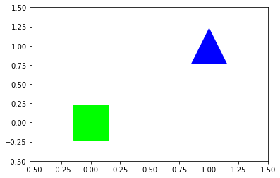

```python
%matplotlib inline
plt.plot(0,0,marker='s',ms=50,color=(0,1,0))
plt.plot(1,1,marker='^',ms=50,color=(0,0,1));
plt.xlim(-0.5,1.5)
plt.ylim(-0.5,1.5);
```

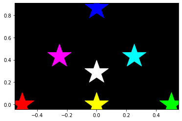

```python
h=(3**0.5)/2
w=0.5

ax=plt.subplot(1,1,1)
plt.plot(-w,0,'*',ms=50,color=(1,0,0)) # red
plt.plot(w,0,'*',ms=50,color=(0,1,0)) # green
plt.plot(0,h,'*',ms=50,color=(0,0,1)) # blue
plt.plot(-w/2,h/2,'*',ms=50,color=(1,0,1)) # red + blue = magenta
plt.plot(w/2,h/2,'*',ms=50,color=(0,1,1)) # green + blue = cyan
plt.plot(0,0,'*',ms=50,color=(1,1,0)) # red + green = yellow
plt.plot(0,h/3,'*',ms=50,color=(1,1,1)) # red + green + blue = white
ax.set_facecolor((0,0,0)) # black background
```

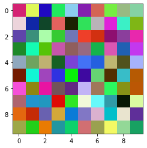

```python
img = np.random.rand(10,10,3)
plt.imshow(img);
```

```python
img[:,:,2] # blue component
```

```
array([[0.45121802, 0.34954146, 0.75364931, 0.36984901, 0.94090519,
        0.68584068, 0.33194238, 0.26060564, 0.51263749, 0.64309801],
       [0.86237608, 0.65832718, 0.16092873, 0.36915614, 0.00537281,
        0.35600638, 0.72339395, 0.85365648, 0.77678546, 0.08931339],
       [0.66675364, 0.48367266, 0.66962255, 0.2015392 , 0.71488756,
        0.16263975, 0.0681279 , 0.44175583, 0.61407235, 0.67934364],
       [0.16120167, 0.70564715, 0.03327269, 0.67072382, 0.36368235,
        0.5089136 , 0.29805857, 0.69893594, 0.70201313, 0.93384313],
       [0.74858686, 0.37388055, 0.4434119 , 0.1392551 , 0.84063857,
        0.96251025, 0.8772231 , 0.44344425, 0.11835453, 0.9876689 ],
       [0.00132015, 0.83254775, 0.73755223, 0.88264216, 0.04183575,
        0.62977139, 0.45150689, 0.00897169, 0.78479682, 0.01204104],
       [0.84755112, 0.07027685, 0.63832198, 0.35319891, 0.51186146,
        0.96760553, 0.35134651, 0.37308631, 0.090669  , 0.02241055],
       [0.43756231, 0.81095083, 0.75246619, 0.02316944, 0.1487857 ,
        0.85295698, 0.98390065, 0.66037115, 0.0182645 , 0.63467273],
       [0.06154895, 0.02463787, 0.69276747, 0.22398129, 0.8432977 ,
        0.77339297, 0.81255951, 0.79598996, 0.81241529, 0.60007101],
       [0.28326636, 0.09962614, 0.00841803, 0.6240831 , 0.42128865,
        0.44878013, 0.31225478, 0.39367516, 0.59320423, 0.38491328]])
```

## Broadcasting of `numpy` arrays

```python
a=np.arange(12).reshape(4,3)
a
```

```
array([[ 0,  1,  2],
       [ 3,  4,  5],
       [ 6,  7,  8],
       [ 9, 10, 11]])
```

```python
a[0,:]=1
a
```

```
array([[ 1,  1,  1],
       [ 3,  4,  5],
       [ 6,  7,  8],
       [ 9, 10, 11]])
```

```python
a[0,:]=np.arange(4)
```

```
---------------------------------------------------------------------------
ValueError                                Traceback (most recent call last)
<ipython-input-87-469c16bfe9f1> in <module>
----> 1 a[0,:]=np.arange(4)

ValueError: could not broadcast input array from shape (4) into shape (3)
```

```python
a+np.arange(4)
```

```
---------------------------------------------------------------------------
ValueError                                Traceback (most recent call last)
<ipython-input-88-a8f7a62ac54d> in <module>
----> 1 a+np.arange(4)

ValueError: operands could not be broadcast together with shapes (4,3) (4,)
```

```python
a=np.arange(12).reshape(4,3)
a
```

```
array([[ 0,  1,  2],
       [ 3,  4,  5],
       [ 6,  7,  8],
       [ 9, 10, 11]])
```

```python
a+np.arange(3)
```

```
array([[ 0,  2,  4],
       [ 3,  5,  7],
       [ 6,  8, 10],
       [ 9, 11, 13]])
```

```python
np.arange(3).shape
```

```
(3,)
```

General idea:

- broadcasting allows you to combine arrays with different dimensions
- dimensions are either matching, or one of them is 1
- the check starts from the last dimension
- two arrays might have different numbers of dimensions

```python
a
```

```
array([[ 0,  1,  2],
       [ 3,  4,  5],
       [ 6,  7,  8],
       [ 9, 10, 11]])
```

```python
a.shape
```

```
(4, 3)
```

```python
b=np.arange(4).reshape(4,1)
b
```

```
array([[0],
       [1],
       [2],
       [3]])
```

```python
b.shape
```

```
(4, 1)
```

```python
a+b
```

```
array([[ 0,  1,  2],
       [ 4,  5,  6],
       [ 8,  9, 10],
       [12, 13, 14]])
```